# Project: Analysising the TMDB Movies Dataset. Analysing factors that effect the revenue of a movie

- Introduction
- Data Wrangling
- Exploratory Data Analysis
- Conclusions

## Introduction

> This data set contains information about 10,000 movies collected from The Movie Database. It has information about a movie's genre, budget, revenue, cast etc. I'm going to focus on variables that can affect the revenue of a movie, like its genre and the month it was released. Is considering the month of release of a movie important for maximum returns? Which genre is more likely to earn more profit?

```python
import pandas as pd
import numpy as np
import matplotlib.pyplot as plt
import seaborn as sns
from datetime import datetime

%matplotlib inline
```

## Data Wrangling

### General Properties

```python
df_m=pd.read_csv('tmdb-movies.csv')
df_m.head(10)
```

|  | id | imdb_id | popularity | budget | revenue | original_title | cast | homepage | director | tagline | ... | overview | runtime | genres | production_companies | release_date | vote_count | vote_average | release_year | budget_adj | revenue_adj |
| --- | --- | --- | --- | --- | --- | --- | --- | --- | --- | --- | --- | --- | --- | --- | --- | --- | --- | --- | --- | --- | --- |
| 0 | 135397 | tt0369610 | 32.985763 | 150000000 | 1513528810 | Jurassic World | Chris Pratt\|Bryce Dallas Howard\|Irrfan Khan\|Vi... | http://www.jurassicworld.com/ | Colin Trevorrow | The park is open. | ... | Twenty-two years after the events of Jurassic ... | 124 | Action\|Adventure\|Science Fiction\|Thriller | Universal Studios\|Amblin Entertainment\|Legenda... | 6/9/15 | 5562 | 6.5 | 2015 | 1.379999e+08 | 1.392446e+09 |
| 1 | 76341 | tt1392190 | 28.419936 | 150000000 | 378436354 | Mad Max: Fury Road | Tom Hardy\|Charlize Theron\|Hugh Keays-Byrne\|Nic... | http://www.madmaxmovie.com/ | George Miller | What a Lovely Day. | ... | An apocalyptic story set in the furthest reach... | 120 | Action\|Adventure\|Science Fiction\|Thriller | Village Roadshow Pictures\|Kennedy Miller Produ... | 5/13/15 | 6185 | 7.1 | 2015 | 1.379999e+08 | 3.481613e+08 |
| 2 | 262500 | tt2908446 | 13.112507 | 110000000 | 295238201 | Insurgent | Shailene Woodley\|Theo James\|Kate Winslet\|Ansel... | http://www.thedivergentseries.movie/#insurgent | Robert Schwentke | One Choice Can Destroy You | ... | Beatrice Prior must confront her inner demons ... | 119 | Adventure\|Science Fiction\|Thriller | Summit Entertainment\|Mandeville Films\|Red Wago... | 3/18/15 | 2480 | 6.3 | 2015 | 1.012000e+08 | 2.716190e+08 |
| 3 | 140607 | tt2488496 | 11.173104 | 200000000 | 2068178225 | Star Wars: The Force Awakens | Harrison Ford\|Mark Hamill\|Carrie Fisher\|Adam D... | http://www.starwars.com/films/star-wars-episod... | J.J. Abrams | Every generation has a story. | ... | Thirty years after defeating the Galactic Empi... | 136 | Action\|Adventure\|Science Fiction\|Fantasy | Lucasfilm\|Truenorth Productions\|Bad Robot | 12/15/15 | 5292 | 7.5 | 2015 | 1.839999e+08 | 1.902723e+09 |
| 4 | 168259 | tt2820852 | 9.335014 | 190000000 | 1506249360 | Furious 7 | Vin Diesel\|Paul Walker\|Jason Statham\|Michelle ... | http://www.furious7.com/ | James Wan | Vengeance Hits Home | ... | Deckard Shaw seeks revenge against Dominic Tor... | 137 | Action\|Crime\|Thriller | Universal Pictures\|Original Film\|Media Rights ... | 4/1/15 | 2947 | 7.3 | 2015 | 1.747999e+08 | 1.385749e+09 |
| 5 | 281957 | tt1663202 | 9.110700 | 135000000 | 532950503 | The Revenant | Leonardo DiCaprio\|Tom Hardy\|Will Poulter\|Domhn... | http://www.foxmovies.com/movies/the-revenant | Alejandro González Iñárritu | (n. One who has returned, as if from the dead.) | ... | In the 1820s, a frontiersman, Hugh Glass, sets... | 156 | Western\|Drama\|Adventure\|Thriller | Regency Enterprises\|Appian Way\|CatchPlay\|Anony... | 12/25/15 | 3929 | 7.2 | 2015 | 1.241999e+08 | 4.903142e+08 |
| 6 | 87101 | tt1340138 | 8.654359 | 155000000 | 440603537 | Terminator Genisys | Arnold Schwarzenegger\|Jason Clarke\|Emilia Clar... | http://www.terminatormovie.com/ | Alan Taylor | Reset the future | ... | The year is 2029. John Connor, leader of the r... | 125 | Science Fiction\|Action\|Thriller\|Adventure | Paramount Pictures\|Skydance Productions | 6/23/15 | 2598 | 5.8 | 2015 | 1.425999e+08 | 4.053551e+08 |
| 7 | 286217 | tt3659388 | 7.667400 | 108000000 | 595380321 | The Martian | Matt Damon\|Jessica Chastain\|Kristen Wiig\|Jeff ... | http://www.foxmovies.com/movies/the-martian | Ridley Scott | Bring Him Home | ... | During a manned mission to Mars, Astronaut Mar... | 141 | Drama\|Adventure\|Science Fiction | Twentieth Century Fox Film Corporation\|Scott F... | 9/30/15 | 4572 | 7.6 | 2015 | 9.935996e+07 | 5.477497e+08 |
| 8 | 211672 | tt2293640 | 7.404165 | 74000000 | 1156730962 | Minions | Sandra Bullock\|Jon Hamm\|Michael Keaton\|Allison... | http://www.minionsmovie.com/ | Kyle Balda\|Pierre Coffin | Before Gru, they had a history of bad bosses | ... | Minions Stuart, Kevin and Bob are recruited by... | 91 | Family\|Animation\|Adventure\|Comedy | Universal Pictures\|Illumination Entertainment | 6/17/15 | 2893 | 6.5 | 2015 | 6.807997e+07 | 1.064192e+09 |
| 9 | 150540 | tt2096673 | 6.326804 | 175000000 | 853708609 | Inside Out | Amy Poehler\|Phyllis Smith\|Richard Kind\|Bill Ha... | http://movies.disney.com/inside-out | Pete Docter | Meet the little voices inside your head. | ... | Growing up can be a bumpy road, and it's no ex... | 94 | Comedy\|Animation\|Family | Walt Disney Pictures\|Pixar Animation Studios\|W... | 6/9/15 | 3935 | 8.0 | 2015 | 1.609999e+08 | 7.854116e+08 |

10 rows × 21 columns

> The genre column has multiple values and the values need to be seperated. The number of multiple values in the column are different for each row

```python
df_m.shape #Size of the dataframe
```

```
(10866, 21)
```

```python
df_m.dtypes
```

```
id                        int64
imdb_id                  object
popularity              float64
budget                    int64
revenue                   int64
original_title           object
cast                     object
homepage                 object
director                 object
tagline                  object
keywords                 object
overview                 object
runtime                   int64
genres                   object
production_companies     object
release_date             object
vote_count                int64
vote_average            float64
release_year              int64
budget_adj              float64
revenue_adj             float64
dtype: object
```

> The datatypes of the column seem to be alright except of the release_date. I'll change it in the Data Cleaning section.

```python
df_m.nunique() #calculate unique values in each column
```

```
id                      10865
imdb_id                 10855
popularity              10814
budget                    557
revenue                  4702
original_title          10571
cast                    10719
homepage                 2896
director                 5067
tagline                  7997
keywords                 8804
overview                10847
runtime                   247
genres                   2039
production_companies     7445
release_date             5909
vote_count               1289
vote_average               72
release_year               56
budget_adj               2614
revenue_adj              4840
dtype: int64
```

```python
df_m.describe()
#computes statistics of numerical columns of the dataframe
```

|  | id | popularity | budget | revenue | runtime | vote_count | vote_average | release_year | budget_adj | revenue_adj |
| --- | --- | --- | --- | --- | --- | --- | --- | --- | --- | --- |
| count | 10866.000000 | 10866.000000 | 1.086600e+04 | 1.086600e+04 | 10866.000000 | 10866.000000 | 10866.000000 | 10866.000000 | 1.086600e+04 | 1.086600e+04 |
| mean | 66064.177434 | 0.646441 | 1.462570e+07 | 3.982332e+07 | 102.070863 | 217.389748 | 5.974922 | 2001.322658 | 1.755104e+07 | 5.136436e+07 |
| std | 92130.136561 | 1.000185 | 3.091321e+07 | 1.170035e+08 | 31.381405 | 575.619058 | 0.935142 | 12.812941 | 3.430616e+07 | 1.446325e+08 |
| min | 5.000000 | 0.000065 | 0.000000e+00 | 0.000000e+00 | 0.000000 | 10.000000 | 1.500000 | 1960.000000 | 0.000000e+00 | 0.000000e+00 |
| 25% | 10596.250000 | 0.207583 | 0.000000e+00 | 0.000000e+00 | 90.000000 | 17.000000 | 5.400000 | 1995.000000 | 0.000000e+00 | 0.000000e+00 |
| 50% | 20669.000000 | 0.383856 | 0.000000e+00 | 0.000000e+00 | 99.000000 | 38.000000 | 6.000000 | 2006.000000 | 0.000000e+00 | 0.000000e+00 |
| 75% | 75610.000000 | 0.713817 | 1.500000e+07 | 2.400000e+07 | 111.000000 | 145.750000 | 6.600000 | 2011.000000 | 2.085325e+07 | 3.369710e+07 |
| max | 417859.000000 | 32.985763 | 4.250000e+08 | 2.781506e+09 | 900.000000 | 9767.000000 | 9.200000 | 2015.000000 | 4.250000e+08 | 2.827124e+09 |

```python
df_m.duplicated().sum() #find duplicate rows
```

```
1
```

> We need to remove this duplicate row because it will not contribute to our analysis.

```python
np.count_nonzero(df_m.isnull()) #find total null values
```

```
13434
```

> Many null values in the dataset. I'll remove this in the next section.

## 2. Data Cleaning

### Dropping columns, null values and duplicate rows

> The following columns can't be used for any kind of analysis I want to perform.

```python
df_m.drop(['homepage', 'tagline','overview'], axis=1, inplace=True)

#drop rows with null values in these columns.
df_m.dropna(subset=['genres', 'original_title', 'production_companies','runtime'], inplace=True)
```

```python
df_m.drop_duplicates(inplace=True)
df_m.duplicated().sum()#Number of duplicate rows
```

```
0
```

```python
np.count_nonzero(df_m.isnull()) #Total null values
```

```
1184
```

### Separating values in Genre column

```python
def safe_access(container, i):
    """Return this value if it exists at index i and if it doesn't, return a null value. Avoids IndexError and KeyError"""
    result = container.split('|')
    try:
        return result[i]
    except IndexError or KeyError:
        return pd.np.nan
```

```python
df_mm=df_m[df_m['genres'].str.contains('|')]#returns rows which have multiple values in genres column.
df_mm.head()
```

|  | id | imdb_id | popularity | budget | revenue | original_title | cast | director | keywords | runtime | genres | production_companies | release_date | vote_count | vote_average | release_year | budget_adj | revenue_adj |
| --- | --- | --- | --- | --- | --- | --- | --- | --- | --- | --- | --- | --- | --- | --- | --- | --- | --- | --- |
| 0 | 135397 | tt0369610 | 32.985763 | 150000000 | 1513528810 | Jurassic World | Chris Pratt\|Bryce Dallas Howard\|Irrfan Khan\|Vi... | Colin Trevorrow | monster\|dna\|tyrannosaurus rex\|velociraptor\|island | 124 | Action\|Adventure\|Science Fiction\|Thriller | Universal Studios\|Amblin Entertainment\|Legenda... | 6/9/15 | 5562 | 6.5 | 2015 | 1.379999e+08 | 1.392446e+09 |
| 1 | 76341 | tt1392190 | 28.419936 | 150000000 | 378436354 | Mad Max: Fury Road | Tom Hardy\|Charlize Theron\|Hugh Keays-Byrne\|Nic... | George Miller | future\|chase\|post-apocalyptic\|dystopia\|australia | 120 | Action\|Adventure\|Science Fiction\|Thriller | Village Roadshow Pictures\|Kennedy Miller Produ... | 5/13/15 | 6185 | 7.1 | 2015 | 1.379999e+08 | 3.481613e+08 |
| 2 | 262500 | tt2908446 | 13.112507 | 110000000 | 295238201 | Insurgent | Shailene Woodley\|Theo James\|Kate Winslet\|Ansel... | Robert Schwentke | based on novel\|revolution\|dystopia\|sequel\|dyst... | 119 | Adventure\|Science Fiction\|Thriller | Summit Entertainment\|Mandeville Films\|Red Wago... | 3/18/15 | 2480 | 6.3 | 2015 | 1.012000e+08 | 2.716190e+08 |
| 3 | 140607 | tt2488496 | 11.173104 | 200000000 | 2068178225 | Star Wars: The Force Awakens | Harrison Ford\|Mark Hamill\|Carrie Fisher\|Adam D... | J.J. Abrams | android\|spaceship\|jedi\|space opera\|3d | 136 | Action\|Adventure\|Science Fiction\|Fantasy | Lucasfilm\|Truenorth Productions\|Bad Robot | 12/15/15 | 5292 | 7.5 | 2015 | 1.839999e+08 | 1.902723e+09 |
| 4 | 168259 | tt2820852 | 9.335014 | 190000000 | 1506249360 | Furious 7 | Vin Diesel\|Paul Walker\|Jason Statham\|Michelle ... | James Wan | car race\|speed\|revenge\|suspense\|car | 137 | Action\|Crime\|Thriller | Universal Pictures\|Original Film\|Media Rights ... | 4/1/15 | 2947 | 7.3 | 2015 | 1.747999e+08 | 1.385749e+09 |

```python
df_mm.shape==df_m.shape #Do all rows have multiple values in genres column?
```

```
True
```

```python
df1=df_mm.copy() #Copies data column
df2=df_mm.copy()
df3=df_mm.copy()
df4=df_mm.copy()
df5=df_mm.copy()
```

> The following lines get each genre from for each movie and adds the row to a data frame. If a value doesn't exist, it stores a null. Later these null values will be deleted and the all dataframes will be appended

```python
df1['genres']=df1['genres'].apply(lambda x: safe_access(x,0))
df2['genres']=df2['genres'].apply(lambda x: safe_access(x,1))
df3['genres']=df3['genres'].apply(lambda x: safe_access(x,2))
df4['genres']=df4['genres'].apply(lambda x: safe_access(x,3))
df5['genres']=df5['genres'].apply(lambda x: safe_access(x,4))
```

```python
print("null values in df1\n", np.count_nonzero(df1['genres'].isnull()))
print("null values in df2\n", np.count_nonzero(df2['genres'].isnull()))
print("null values in df3\n", np.count_nonzero(df3['genres'].isnull()))
print("null values in df4\n", np.count_nonzero(df4['genres'].isnull()))
print("null values in df5\n", np.count_nonzero(df5['genres'].isnull()))
```

```
null values in df1
 0
null values in df2
 1982
null values in df3
 5101
null values in df4
 7972
null values in df5
 9318
```

Need to drop all rows which have null values in the genres column in the new dataframe (df1, df2..) to avoid redundancy.

```python
df1.dropna(subset=['genres'],inplace=True) #drop null values from the genres column
df2.dropna(subset=['genres'],inplace=True)
df3.dropna(subset=['genres'],inplace=True)
df4.dropna(subset=['genres'],inplace=True)
df5.dropna(subset=['genres'],inplace=True)
```

```python
print("null values in df1\n", np.count_nonzero(df1['genres'].isnull()))
print("null values in df2\n", np.count_nonzero(df2['genres'].isnull()))
print("null values in df3\n", np.count_nonzero(df3['genres'].isnull()))
print("null values in df4\n", np.count_nonzero(df4['genres'].isnull()))
print("null values in df5\n", np.count_nonzero(df5['genres'].isnull()))
```

```
null values in df1
 0
null values in df2
 0
null values in df3
 0
null values in df4
 0
null values in df5
 0
```

```python
df1=df1.append(df2, ignore_index=True)
df3=df3.append(df4,ignore_index=True)
df3=df3.append(df5,ignore_index=True)
new_df=df1.append(df3,ignore_index=True)
new_df.shape
```

```
(24757, 18)
```

### Changing datatype of release_date to timestamp from String

```python
type(new_df['release_date'][0])==str #Checks if release_date column is of type string
```

```
True
```

```python
new_df['release_date']=pd.to_datetime(new_df['release_date'])
type(new_df['release_date'][0]) #data type of release_date column
```

```
pandas._libs.tslib.Timestamp
```

### Adding new column release_month for further analysis

```python
new_df['release_month']=new_df['release_date'].apply(lambda x: x.to_datetime().month)
new_df.head()
```

|  | id | imdb_id | popularity | budget | revenue | original_title | cast | director | keywords | runtime | genres | production_companies | release_date | vote_count | vote_average | release_year | budget_adj | revenue_adj | release_month |
| --- | --- | --- | --- | --- | --- | --- | --- | --- | --- | --- | --- | --- | --- | --- | --- | --- | --- | --- | --- |
| 0 | 135397 | tt0369610 | 32.985763 | 150000000 | 1513528810 | Jurassic World | Chris Pratt\|Bryce Dallas Howard\|Irrfan Khan\|Vi... | Colin Trevorrow | monster\|dna\|tyrannosaurus rex\|velociraptor\|island | 124 | Action | Universal Studios\|Amblin Entertainment\|Legenda... | 2015-06-09 | 5562 | 6.5 | 2015 | 1.379999e+08 | 1.392446e+09 | 6 |
| 1 | 76341 | tt1392190 | 28.419936 | 150000000 | 378436354 | Mad Max: Fury Road | Tom Hardy\|Charlize Theron\|Hugh Keays-Byrne\|Nic... | George Miller | future\|chase\|post-apocalyptic\|dystopia\|australia | 120 | Action | Village Roadshow Pictures\|Kennedy Miller Produ... | 2015-05-13 | 6185 | 7.1 | 2015 | 1.379999e+08 | 3.481613e+08 | 5 |
| 2 | 262500 | tt2908446 | 13.112507 | 110000000 | 295238201 | Insurgent | Shailene Woodley\|Theo James\|Kate Winslet\|Ansel... | Robert Schwentke | based on novel\|revolution\|dystopia\|sequel\|dyst... | 119 | Adventure | Summit Entertainment\|Mandeville Films\|Red Wago... | 2015-03-18 | 2480 | 6.3 | 2015 | 1.012000e+08 | 2.716190e+08 | 3 |
| 3 | 140607 | tt2488496 | 11.173104 | 200000000 | 2068178225 | Star Wars: The Force Awakens | Harrison Ford\|Mark Hamill\|Carrie Fisher\|Adam D... | J.J. Abrams | android\|spaceship\|jedi\|space opera\|3d | 136 | Action | Lucasfilm\|Truenorth Productions\|Bad Robot | 2015-12-15 | 5292 | 7.5 | 2015 | 1.839999e+08 | 1.902723e+09 | 12 |
| 4 | 168259 | tt2820852 | 9.335014 | 190000000 | 1506249360 | Furious 7 | Vin Diesel\|Paul Walker\|Jason Statham\|Michelle ... | James Wan | car race\|speed\|revenge\|suspense\|car | 137 | Action | Universal Pictures\|Original Film\|Media Rights ... | 2015-04-01 | 2947 | 7.3 | 2015 | 1.747999e+08 | 1.385749e+09 | 4 |

```python
#changes month number to month name in release_month
new_df['release_month']= new_df['release_month'].map({1:'January', 2:'February', 3:'March', 4:'April', 5:'May', 6:'June', 7:'July', 8:'August', 9:'September', 10:'October', 11:'November', 12:'December'})
new_df.head()
```

|  | id | imdb_id | popularity | budget | revenue | original_title | cast | director | keywords | runtime | genres | production_companies | release_date | vote_count | vote_average | release_year | budget_adj | revenue_adj | release_month |
| --- | --- | --- | --- | --- | --- | --- | --- | --- | --- | --- | --- | --- | --- | --- | --- | --- | --- | --- | --- |
| 0 | 135397 | tt0369610 | 32.985763 | 150000000 | 1513528810 | Jurassic World | Chris Pratt\|Bryce Dallas Howard\|Irrfan Khan\|Vi... | Colin Trevorrow | monster\|dna\|tyrannosaurus rex\|velociraptor\|island | 124 | Action | Universal Studios\|Amblin Entertainment\|Legenda... | 2015-06-09 | 5562 | 6.5 | 2015 | 1.379999e+08 | 1.392446e+09 | June |
| 1 | 76341 | tt1392190 | 28.419936 | 150000000 | 378436354 | Mad Max: Fury Road | Tom Hardy\|Charlize Theron\|Hugh Keays-Byrne\|Nic... | George Miller | future\|chase\|post-apocalyptic\|dystopia\|australia | 120 | Action | Village Roadshow Pictures\|Kennedy Miller Produ... | 2015-05-13 | 6185 | 7.1 | 2015 | 1.379999e+08 | 3.481613e+08 | May |
| 2 | 262500 | tt2908446 | 13.112507 | 110000000 | 295238201 | Insurgent | Shailene Woodley\|Theo James\|Kate Winslet\|Ansel... | Robert Schwentke | based on novel\|revolution\|dystopia\|sequel\|dyst... | 119 | Adventure | Summit Entertainment\|Mandeville Films\|Red Wago... | 2015-03-18 | 2480 | 6.3 | 2015 | 1.012000e+08 | 2.716190e+08 | March |
| 3 | 140607 | tt2488496 | 11.173104 | 200000000 | 2068178225 | Star Wars: The Force Awakens | Harrison Ford\|Mark Hamill\|Carrie Fisher\|Adam D... | J.J. Abrams | android\|spaceship\|jedi\|space opera\|3d | 136 | Action | Lucasfilm\|Truenorth Productions\|Bad Robot | 2015-12-15 | 5292 | 7.5 | 2015 | 1.839999e+08 | 1.902723e+09 | December |
| 4 | 168259 | tt2820852 | 9.335014 | 190000000 | 1506249360 | Furious 7 | Vin Diesel\|Paul Walker\|Jason Statham\|Michelle ... | James Wan | car race\|speed\|revenge\|suspense\|car | 137 | Action | Universal Pictures\|Original Film\|Media Rights ... | 2015-04-01 | 2947 | 7.3 | 2015 | 1.747999e+08 | 1.385749e+09 | April |

### Shorten few genre values because they are too long

```python
new_df['genres']=new_df['genres'].replace({'Science Fiction':"Sci Fiction", "Documentary":"Doc'tary", "Adventure":"Adv're"})
new_df['genres'].unique()
```

```
array(['Action', "Adv're", 'Western', 'Sci Fiction', 'Drama', 'Family',
       'Comedy', 'Crime', 'Romance', 'War', 'Mystery', 'Thriller',
       'Fantasy', 'History', 'Animation', 'Horror', 'Music', "Doc'tary",
       'TV Movie', 'Foreign'], dtype=object)
```

> Adventure --> Adv're  
> Science Fiction --> Sci Fiction  
> Documentart --> Doc'tary

## 3. Exploratory Data Analysis

### Which Genre has the highest revenue?

> I'm gonna groupby genre of the movies and find the revenue_adj mean and compare them. Even if a single movie has multiple genres, this method will give the right result because for each each movie, each corresponding genre gets equal weight of the revenue. And the number of movies with a particular genre shouldn't affect much because I'm taking the average.

```python
mean_revenues=new_df.groupby('genres')['revenue_adj'].mean()
mean_revenues
```

```
genres
Action         9.763580e+07
Adv're         1.498139e+08
Animation      9.287552e+07
Comedy         5.271744e+07
Crime          5.902647e+07
Doc'tary       3.292831e+06
Drama          4.394511e+07
Family         9.738196e+07
Fantasy        1.207935e+08
Foreign        1.918406e+06
History        5.198219e+07
Horror         2.579533e+07
Music          5.562651e+07
Mystery        5.322556e+07
Romance        5.243856e+07
Sci Fiction    9.363840e+07
TV Movie       4.325119e+05
Thriller       5.843933e+07
War            7.295850e+07
Western        4.754193e+07
Name: revenue_adj, dtype: float64
```

```
[0, 1, 2, 3, 4, 5, 6, 7, 8, 9, 10, 11, 12, 13, 14, 15, 16, 17, 18, 19]
[50, 20]
```

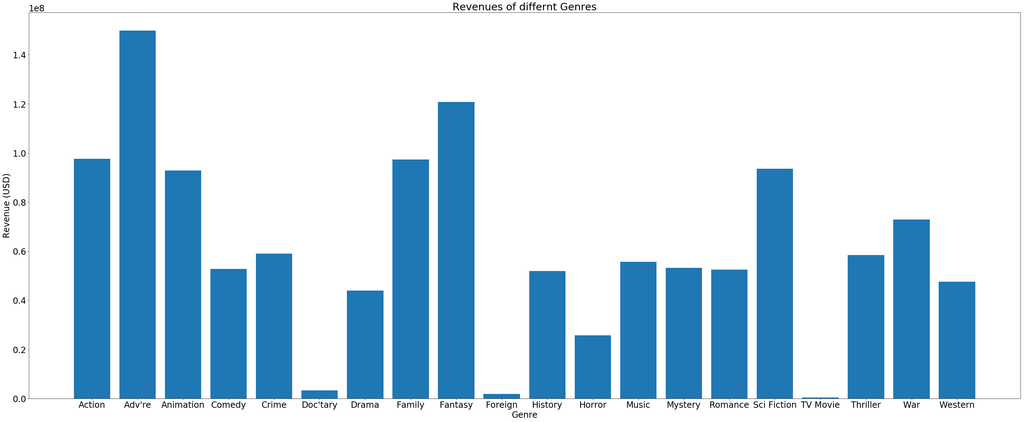

```python
locations=[i for i in range(mean_revenues.count())]
print(locations)
labels= mean_revenues.keys()
height=mean_revenues.values
plt.bar(locations, height, tick_label=labels) #Plot the bar chart
#Set title of the bar chart
plt.title("Revenues of differnt Genres")

#x-axis label
plt.xlabel("Genre")

#y-axis label
plt.ylabel("Revenue (USD)")
fig_size = plt.rcParams["figure.figsize"]
fig_size[0]=50
fig_size[1]=20
print(fig_size)
plt.rcParams["figure.figsize"]= fig_size #Set the size of the plot
plt.rcParams.update({'font.size': 24}) #Sets the fontsize
```

> Adventure movies have the highest revenue and TV Movie have the least revenue.

### Does runtime of a movie depend on its genre? Is there any significant difference between the runtimes of each genre?

> I'm going to plot the runtime of each movie corresponding to its genre. If the distribution is along same/close horizontal axis, there is no significant difference in the runtime of each genre.

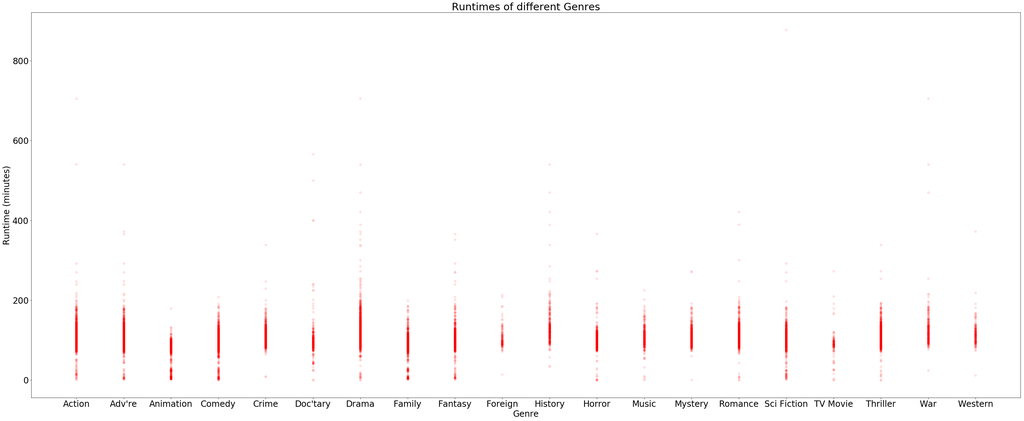

```python
plt.scatter(new_df['genres'],new_df['runtime'], color='r', alpha=0.1) #plot a scatter plot with high transparency (alpha)
plt.title('Runtimes of different Genres')
plt.ylabel("Runtime (minutes)")
plt.xlabel("Genre")
plt.rcParams['figure.figsize'] = [50,20]
plt.rcParams.update({'font.size': 30})
```

### Which month is the best for the movie release?

> This is a very intersting question because the production companies can target this month for maximum returns. Taking the mean revenue values for each month and plotting a bar graph should give a good idea to answer the question.

```python
months_dict = {"January":1, "February":2, "March":3, "April":4, "May":5, "June":6, "July":7, "August":8, "September":9, "October":10, "November":11, "December":12 }

def month_value(date):
    return months_dict[date]
```

```python
month_revenues=new_df.groupby('release_month')['revenue_adj'].mean()
month_revenues
```

```
release_month
April        5.210252e+07
August       4.236415e+07
December     1.014656e+08
February     3.965993e+07
January      2.691735e+07
July         9.613436e+07
June         1.243722e+08
March        6.334589e+07
May          9.901106e+07
November     9.147676e+07
October      4.265785e+07
September    2.968905e+07
Name: revenue_adj, dtype: float64
```

**Need to sort the month list in ascending order of the months in the calendar and not their first letter**

```python
keys=month_revenues.keys()
sorted_month=sorted(keys, key=month_value)
#This sorts the month in the right order using the dictionary month_dict defined above. Uses the value of the month as the key to sort it.
sorted_month
```

```
['January',
 'February',
 'March',
 'April',
 'May',
 'June',
 'July',
 'August',
 'September',
 'October',
 'November',
 'December']
```

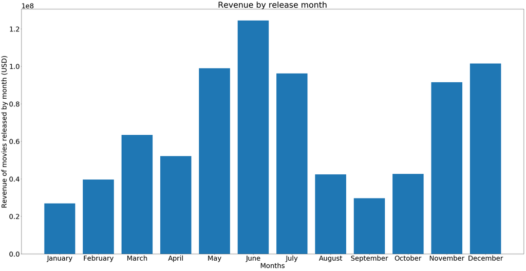

```python
locations=[i for i in range(month_revenues.count())]
height=[month_revenues[i] for i in sorted_month] #to have the values in order.
#Can't use the series keys directly because it sorts by first character
labels=sorted_month
plt.bar(locations, height, tick_label=labels)
plt.rcParams['figure.figsize'] = [40,20]
plt.xlabel('Months')
plt.ylabel('Revenue of movies released by month (USD)')
plt.title('Revenue by release month')
plt.rcParams.update({'font.size': 30})
```

> The movies released in June seem have the highest return compared to other months.

## 4. Conclusions

> **1**: Adventure movies seem to have higher revenue than movies of other genre.

> **2**: Runtime of a movie doesn't really depend on the genre.

> **3**: Movies released in the month of June have higher revenue than movies released in any other month.

**Limitation of the analysis**

> The cast of the movie was not considered which can also have a huge impact on the revenue of a movie and may be the movies with higher revenue (adventure or released in June) casted many favorite celebrities.

> The movies in this dataset have similar runtime and their might be factors that affect the runtime of a movie.

**References**

> Stack Overflow

> Python Documentation

> Idea of safe_access from [Sohier's code](https://www.kaggle.com/sohier/getting-imdb-kernels-working-with-tmdb-data)

```python
from subprocess import call
call(['python', '-m', 'nbconvert', 'Investigate_a_Dataset.ipynb'])
```

```
0
```